# User-defined functions

NIMBLE training materials module

NIMBLE Development Team

# Introduction

NIMBLE provides a variety of functions for use in BUGS code, as seen in Section 5.2.4 of the [NIMBLE manual](http://r-nimble.org/manuals/NimbleUserManual.pdf).

However, there are lots of other calculations that you might want to do in BUGS code. So NIMBLE allows you to code up your own function and then use it in BUGS code. Since these functions are compiled to C++, this can be a good way to increase computational efficiency.

# Basic example

We’ll start with a silly example. Suppose you needed to take a parameter vector in a model and multiple all the elements by two. You could just do this in the BUGS code itself, but we’ll illustrate doing this in a user-defined function. User-defined functions are just nimbleFunctions that have only run-time code; more information is available in the *compile_R* module.

Here’s the user-defined function.

```r
mult2 <- nimbleFunction(
      run = function(x = double(1)) {
        returnType(double(1))
        return(2*x)
      }
)
```

# Using the function in BUGS code

Now let’s use that function in BUGS code.

```r
code <- nimbleCode({
     for(i in 1:n)
           y[i] ~ dnorm(mu[i], sd = sigma)
     mu[1:n] <- mult2(lambda[1:n])
     lambda[1:n] ~ dmnorm(mu0[1:n], C[1:n, 1:n])
})
n <- 10
data <- list(y = rnorm(n))
inits <- list(mu0 = rep(1, n), C = diag(rep(1, n)),
      sigma = 1)
model <- nimbleModel(code, constants = list(n = n),
      data = data, inits = inits)
```

```
## defining model...
```

```
## building model...
```

```
## setting data and initial values...
```

```
## checking model...   (use nimbleModel(..., check = FALSE) to skip model check)
```

```
## NAs were detected in model variables: lambda, logProb_lambda, mu, logProb_y.
```

```
## model building finished
```

```r
model$simulate('lambda')
model$lambda
```

```
##  [1]  2.04655941  1.18330152  0.82286287  1.15930616  2.66132291
##  [6]  1.65377395  1.23152524 -0.05813459  0.62134281 -0.14112587
```

```r
model$mu
```

```
##  [1] NA NA NA NA NA NA NA NA NA NA
```

```r
model$calculate('mu')
```

```
## [1] 0
```

```r
model$mu
```

```
##  [1]  4.0931188  2.3666030  1.6457257  2.3186123  5.3226458  3.3075479
##  [7]  2.4630505 -0.1162692  1.2426856 -0.2822517
```

# A real example

Covariance matrices that are parameterized by hyperparameters are commonly used in longitudinal, spatial, and assorted random effects model contexts.

Let’s consider constructing a covariance matrix for temporally-correlated random effects using a user-defined function. One could do this directly using for loops in BUGS code, but it will be more computationally efficient to do it in a user-defined function.

At the moment, we don’t have an *outer* function in the NIMBLE DSL so we’ll have to write this as two for loops. Computationally that’s not a problem because NIMBLE will compile the function to C++ where for loops are fast.

```r
expcov <- nimbleFunction(
   run = function(times = double(1), rho = double(0), tau = double(0)) {
      returnType(double(2))
      n <- length(times)
      declare(result, double(2, c(n, n)))
      setSize(result, c(n, n))
      for(i in 1:n)
            for(j in 1:n)
                  result[i, j] <- tau*tau*exp(-abs(times[i]-times[j])/rho)
      return(result)
})
```

Let’s generate some time series data.

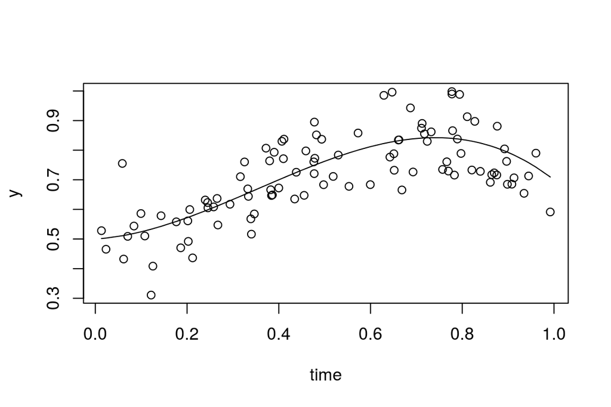

```r
nT <- 100
set.seed(0)
times <- sort(runif(nT))
betas <- c(0.5, .1, 1.6, -1.5)
f <- betas[1] + betas[2]*times + betas[3]*times^2 + betas[4]*times^3
y <- rnorm(nT, f, 0.1)
plot(times, y, xlab = "time", ylab = "y")
lines(times, f)
```

# Real example: Building the model

```r
code <- nimbleCode({
       for(i in 1:T)
             y[i] ~ dnorm(b[i], sd = sigma)

       C[1:T,1:T] <- expcov(times[1:T], rho, tau)
       mn[1:T] <- ones[1:T]*mu
       b[1:T] ~ dmnorm(mn[1:T], cov = C[1:T, 1:T])
       mu ~ dnorm(0, sd = 10)
       sigma ~ dunif(0, 10)
       rho ~ dunif(-1, 1)
       tau ~ dunif(0, 10)
})
inits <- list(mu = 0, rho = .2, tau = 1, sigma = 1)
inits$C <- expcov(times, inits$rho, inits$tau)
inits$b <- t(chol(inits$C)) %*% rnorm(nT)
model <- nimbleModel(code, data = list(y = y),
      constants = list(T = nT, times = times, ones = rep(1, nT)),
      inits = inits)
```

```
## defining model...
```

```
## building model...
```

```
## setting data and initial values...
```

```
## checking model...   (use nimbleModel(..., check = FALSE) to skip model check)
```

```
## model building finished
```

```r
Cmodel <- compileNimble(model)
```

# Real example: Fitting via MCMC

Here we note that by using a vectorized representation of *b*, there is a single node for *b*, so the default sampler for *b* is a block sampler on all of its elements. We know that the elements of *b* are correlated; plus, using a single block sampler will take good computational advantage of having a single node, so this is a good choice.

```r
conf <- configureMCMC(model)
conf$getSamplers()
```

```
## [[1]]
## RW sampler acting on mu
## [[2]]
## RW sampler acting on sigma
## [[3]]
## RW sampler acting on rho
## [[4]]
## RW sampler acting on tau
## [[5]]
## RW_block sampler acting on b[1:100]
```

```r
conf$addMonitors('b')
```

```
## thin = 1: mu, sigma, rho, tau, b
```

```r
mcmc <- buildMCMC(conf)
Cmcmc <- compileNimble(mcmc, project = model)
niter <- 10000
Cmcmc$run(niter)
```

```r
samples <- as.matrix(Cmcmc$mvSamples)
```

And let’s look at the MCMC performance and the model fit.

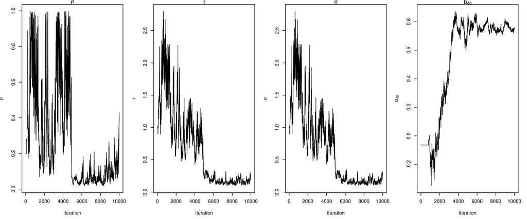

```r
tsplot <- function(x, ...) plot(seq_along(x), x, type = 'l', ...)
par(mfrow = c(1, 4), mai = c(.6, .5, .1, .2))
tsplot(samples[ , 'rho'], xlab = 'iteration',
     ylab = expression(rho), main = expression(rho))
tsplot(samples[ , 'tau'], xlab = 'iteration',
     ylab = expression(tau), main = expression(tau))
tsplot(samples[ , 'tau'], xlab = 'iteration',
     ylab = expression(sigma), main = expression(sigma))
tsplot(samples[ , 'b[40]'], xlab = 'iteration',
     ylab = expression(b[40]), main = expression(b[40]))
```

Ok, that’s not so good, though by iteration 5000, it seems that the model may have settled on the bulk of the posterior.

How does the fit look in the second half of the samples? It looks like the exponential covariance is not inducing enough smoothness in the fit (though of course we only know that because we simulated the data).

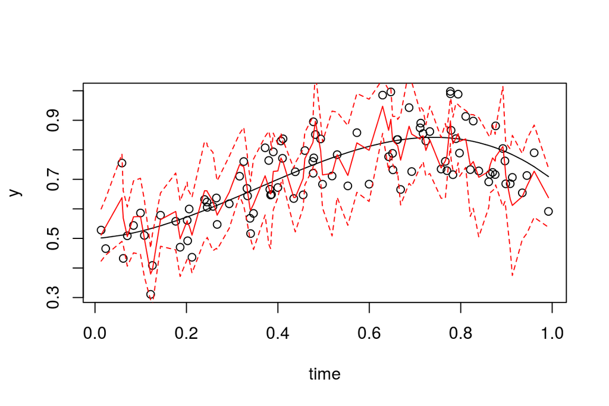

```r
postBurn <- 5001:niter
bMean <- apply(samples[postBurn, 1:nT], 2, mean)
bSD <- apply(samples[postBurn, 1:nT], 2, sd)

plot(times, y, xlab = "time", ylab = "y")
lines(times, f)
lines(times, bMean, col = 'red')
lines(times, bMean + 2*bSD, col = 'red', lty = 2)
lines(times, bMean - 2*bSD, col = 'red', lty = 2)
```